# Quality Control: Non-hashed cells

Ramon Massoni-Badosa

4/20/2020

# 1 Introduction

According to [Luecken MD et al.](https://www.embopress.org/doi/10.15252/msb.20188746), “if the distribution of QC covariates differ between samples, QC thresholds should be determined separately for each sample”. As hashed and non-hashed samples have different library size distributions, the thresholds that separate good- from poor-quality cells will therefore be different. In this notebook, we will filter out low-quality cells and genes for non-hashed samples.

# 2 Pre-processing

## 2.1 Load packages

```r
library(Seurat)
library(ggpubr)
library(tidyverse)
```

## 2.2 Parameters

```r
# Paths
path_to_merged <- here::here("scRNA-seq/results/R_objects/seurat_non_hashed_merged.rds")
path_to_project_metadata <- here::here("scRNA-seq/1-cellranger_mapping/data/tonsil_atlas_metadata.csv")
path_to_donor_metadata <- here::here("data/tonsil_atlas_donor_metadata.csv")
path_to_save_obj <- here::here("scRNA-seq/results/R_objects/seurat_non_hashed_merged_filtered.rds")


# Functions
source(here::here("scRNA-seq/bin/utils.R"))


# Thresholds
min_lib_size <- 1000
max_lib_size <- 40000
min_n_genes <- 250
max_n_genes <- 6000
max_pct_mt <- 20
min_cells <- 5
```

## 2.3 Load data

```r
# Read merged Seurat object
tonsil_non_hashed <- readRDS(path_to_merged)
tonsil_non_hashed
```

```
## An object of class Seurat
## 36601 features across 68851 samples within 1 assay
## Active assay: RNA (36601 features, 0 variable features)
```

```r
# Read project and donor metadata
metadata_df <- read_csv(path_to_project_metadata)
DT::datatable(metadata_df)
```

|  | subproject | gem_id | library_id | library_name | type | donor_id |
| --- | --- | --- | --- | --- | --- | --- |
| 1 | BCLLATLAS_05 | jb6vuao4_g4vi9ur0 | 130339 | BCLL_2_T_5K | not_hashed | BCLL-2-T |
| 2 | BCLLATLAS_05 | izi9unx1_8qdzhivu | 130340 | BCLL_2_T_hashing | hashed_cdna | BCLL-2-T |
| 3 | BCLLATLAS_05 | izi9unx1_8qdzhivu | 130342 | BCLL_2_T_HTO | hashed_hto | BCLL-2-T |
| 4 | BCLLATLAS_06 | wkup7hvl_reo7jg84 | 135347 | BCLL_8_T_5K | not_hashed | BCLL-8-T |
| 5 | BCLLATLAS_06 | d8kwy76j_7blj9otf | 135345 | BCLL_8_T_1_hashing | hashed_cdna | BCLL-8-T |
| 6 | BCLLATLAS_06 | d8kwy76j_7blj9otf | 135348 | BCLL_8_T_1_HTO | hashed_hto | BCLL-8-T |
| 7 | BCLLATLAS_06 | giz3qso4_783dbpu6 | 135346 | BCLL_8_T_2_hashing | hashed_cdna | BCLL-8-T |
| 8 | BCLLATLAS_06 | giz3qso4_783dbpu6 | 135349 | BCLL_8_T_2_HTO | hashed_hto | BCLL-8-T |
| 9 | BCLLATLAS_07 | indj51br_urakqcmi | 135392 | BCLL_9_T_5K | not_hashed | BCLL-9-T |
| 10 | BCLLATLAS_07 | umt51kfr_p8ei65ms | 135390 | BCLL_9_T_1_hashing | hashed_cdna | BCLL-9-T |

[output cut: 36 more lines]

```r
donor_id_df <- read_csv(path_to_donor_metadata)
DT::datatable(donor_id_df)
```

|  | donor_id | hospital | sex | age | age_group |
| --- | --- | --- | --- | --- | --- |
| 1 | BCLL-2-T | Clinic | male | 65 | old_adult |
| 2 | BCLL-6-T | Clinic | male | 35 | young_adult |
| 3 | BCLL-8-T | CIMA | male | 4 | kid |
| 4 | BCLL-9-T | CIMA | male | 5 | kid |
| 5 | BCLL-10-T | CIMA | male | 3 | kid |
| 6 | BCLL-11-T | CIMA | female | 5 | kid |
| 7 | BCLL-12-T | CIMA | female | 3 | kid |
| 8 | BCLL-13-T | CIMA | female | 5 | kid |
| 9 | BCLL-14-T | CIMA | male | 26 | young_adult |
| 10 | BCLL-15-T | CIMA | male | 33 | young_adult |

# 3 Distribution of QC variables

First, we want to see how the main QC variables distribute across samples. This will help us interpret the results downstream, as we will know which are the samples with lower quality.

## 3.1 Library complexity

```r
# Calculate mean library size
n_features_means_df <- tonsil_non_hashed@meta.data %>%
  dplyr::group_by(library_name) %>%
  dplyr::summarise(
    mean_n_features = round(mean(nFeature_RNA), 2),
    sd_n_features = round(sd(nFeature_RNA), 2)) %>%
  dplyr::arrange(mean_n_features)
DT::datatable(n_features_means_df)
```

|  | library_name | mean_n_features | sd_n_features |
| --- | --- | --- | --- |
| 1 | BCLL_2_T_5K | 671.43 | 419.13 |
| 2 | BCLL_11_T_5K | 893.89 | 611.44 |
| 3 | BCLL_14_T_5K | 894.6 | 570.59 |
| 4 | BCLL_10_T_5K | 1166.16 | 881.22 |
| 5 | BCLL_13_T_5K | 1199.96 | 861.03 |
| 6 | BCLL_9_T_5K | 1439.57 | 1027.13 |
| 7 | BCLL_8_T_5K | 1582.97 | 1117.57 |
| 8 | BCLL_12_T_5K | 1922.49 | 1323.74 |

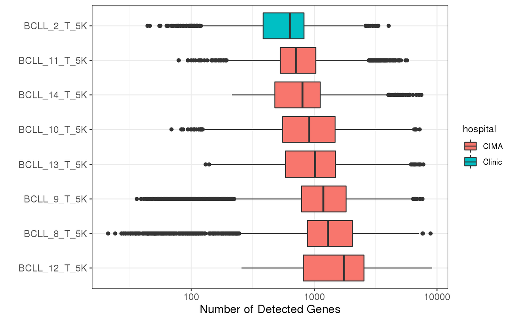

```r
# Plot library size distribution
n_features_gg <- tonsil_non_hashed@meta.data %>%
  horizontal_boxplot(
    categorical_var = "library_name",
    continuous_var = "nFeature_RNA",
    fill = "hospital",
    ylab = "Number of Detected Genes",
    decreasing = TRUE
  ) +
  scale_y_log10()
n_features_gg
```

# 4 Filter out cells

We aim to detect and exclude empty droplets or lysed cells. Lysed cells have 3 hallmarks: (1) low library size (total UMI), (2) low library complexity (number of detected genes) and (3) high fraction of mitochondrial expression (cytosolic mRNA leaks out of the cell). Let us start by visualizing their univariate distributions.

## 4.1 Library Size

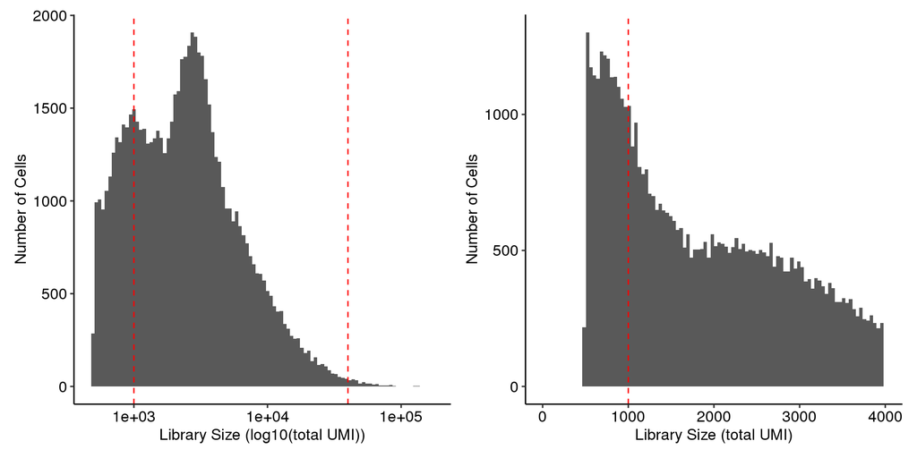

```r
lib_size_hist <- tonsil_non_hashed@meta.data %>%
  plot_histogram_qc(x = "nCount_RNA", x_lab = "Library Size (log10(total UMI))") +
  geom_vline(xintercept = min_lib_size, linetype = "dashed", color = "red")
lib_size_hist1 <- lib_size_hist +
    scale_x_log10() +
    geom_vline(xintercept = max_lib_size, linetype = "dashed", color = "red")
lib_size_hist2 <- lib_size_hist +
    scale_x_continuous(limits = c(0, 4000)) +
    xlab("Library Size (total UMI)") +
    theme_pubr()
lib_size_hist1 + lib_size_hist2
```

## 4.2 Number of detected genes

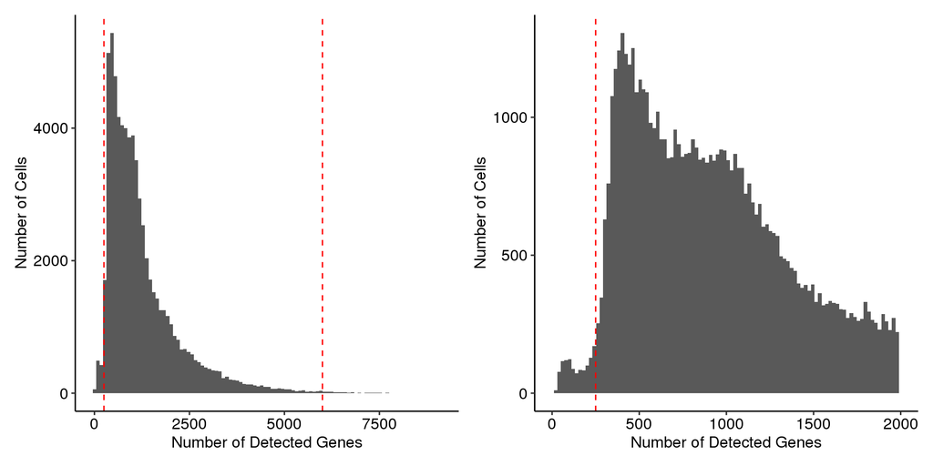

```r
n_genes_hist1 <- tonsil_non_hashed@meta.data %>%
  plot_histogram_qc(x = "nFeature_RNA", x_lab = "Number of Detected Genes") +
  geom_vline(xintercept = min_n_genes, linetype = "dashed", color = "red") +
  geom_vline(xintercept = max_n_genes, linetype = "dashed", color = "red")
n_genes_hist2 <- n_genes_hist1 +
  scale_x_continuous(limits = c(0, 2000))
n_genes_hist1 + n_genes_hist2
```

## 4.3 Fraction of mitochondrial expression

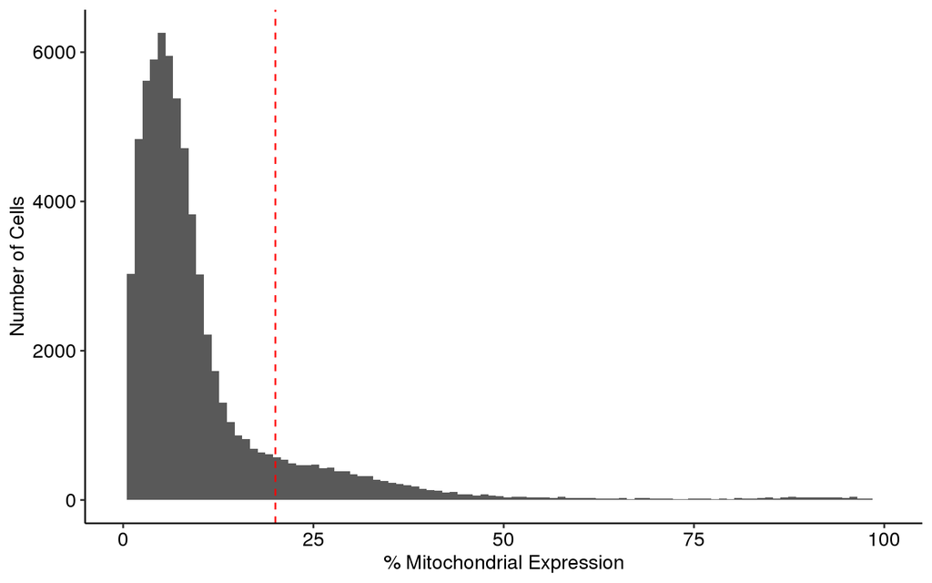

```r
tonsil_non_hashed$pct_mt <- PercentageFeatureSet(
  tonsil_non_hashed,
  pattern = "^MT-"
)
pct_mt_hist <- tonsil_non_hashed@meta.data %>%
  plot_histogram_qc(x = "pct_mt", x_lab = "% Mitochondrial Expression") +
  geom_vline(xintercept = max_pct_mt, linetype = "dashed", color = "red") +
  scale_x_continuous(limits = c(0, 100))
pct_mt_hist
```

## 4.4 Fraction of ribosomal expression

Let us also calculate and visualize the proportion of ribosomal expression:

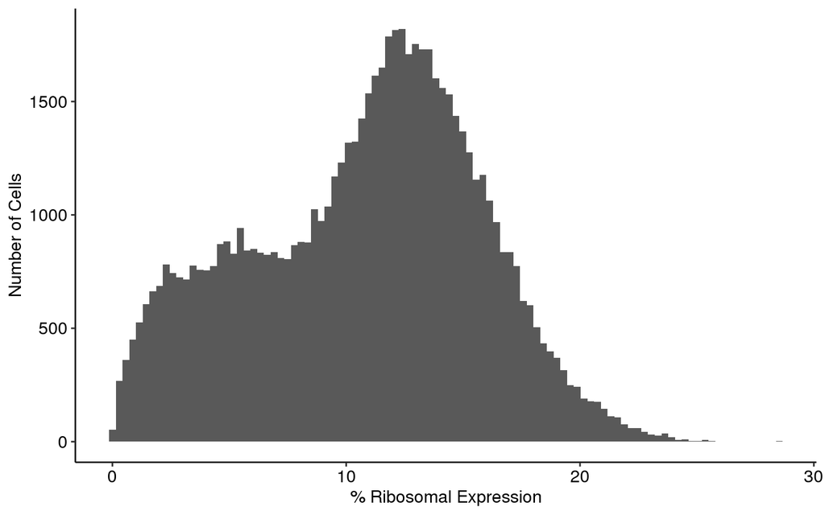

```r
tonsil_non_hashed$pct_ribosomal <- PercentageFeatureSet(
  tonsil_non_hashed,
  pattern = "^RPS"
)
pct_ribosomal_hist <- tonsil_non_hashed@meta.data %>%
  plot_histogram_qc(x = "pct_ribosomal", x_lab = "% Ribosomal Expression")
pct_ribosomal_hist
```

## 4.5 Joint QC metrics

It is important to assess how these variables covary, since metabolically active cells might also have a high mitochondrial expression:

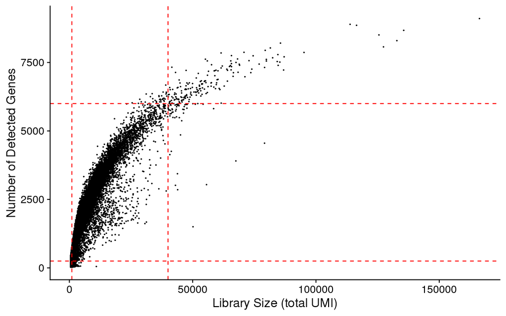

```r
# number of detected genes VS library size
n_genes_vs_lib_size <- FeatureScatter(
  tonsil_non_hashed,
  feature1 = "nCount_RNA",
  feature2 = "nFeature_RNA",
  pt.size = 0.15,
  cols = rep("black", length(levels(Idents(tonsil_non_hashed))))
)
n_genes_vs_lib_size <- n_genes_vs_lib_size +
  labs(x = "Library Size (total UMI)", y = "Number of Detected Genes") +
  theme(legend.position = "none", plot.title = element_blank())
n_genes_vs_lib_size +
  geom_vline(xintercept = min_lib_size, linetype = "dashed", color = "red") +
  geom_hline(yintercept = min_n_genes, linetype = "dashed", color = "red") +
  geom_vline(xintercept = max_lib_size, linetype = "dashed", color = "red") +
  geom_hline(yintercept = max_n_genes, linetype = "dashed", color = "red")
```

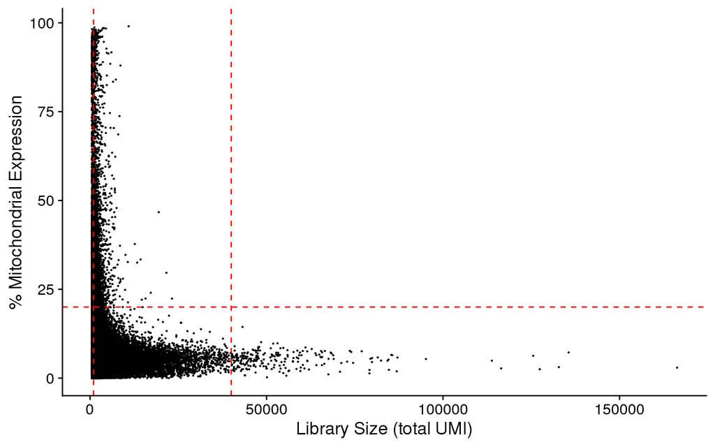

```r
# % mitochondrial expression VS library size
pct_mt_vs_lib_size <- FeatureScatter(
  tonsil_non_hashed,
  feature1 = "nCount_RNA",
  feature2 = "pct_mt",
  pt.size = 0.15,
  cols = rep("black", length(levels(Idents(tonsil_non_hashed))))
)
pct_mt_vs_lib_size <- pct_mt_vs_lib_size +
  labs(x = "Library Size (total UMI)", y = "% Mitochondrial Expression") +
  theme(legend.position = "none", plot.title = element_blank())
pct_mt_vs_lib_size +
  geom_vline(xintercept = min_lib_size, linetype = "dashed", color = "red") +
  geom_hline(yintercept = max_pct_mt, linetype = "dashed", color = "red") +
  geom_vline(xintercept = max_lib_size, linetype = "dashed", color = "red")
```

## 4.6 Subset empty droplets and lysed cells

```r
metadata_before_qc <- tonsil_non_hashed@meta.data
is_low_quality <-
  tonsil_non_hashed$nCount_RNA < min_lib_size |
  tonsil_non_hashed$nFeature_RNA < min_n_genes |
  tonsil_non_hashed$pct_mt > max_pct_mt
table(is_low_quality)
```

```
## is_low_quality
## FALSE  TRUE
## 50072 18779
```

```r
tonsil_non_hashed$keep_cells <- !is_low_quality
Idents(tonsil_non_hashed) <- "keep_cells"
tonsil_non_hashed <- subset(tonsil_non_hashed, idents = TRUE)
metadata_after_qc <- tonsil_non_hashed@meta.data
```

## 4.7 Annotate potential doublets

To aid in the detection and exclusion of doublets, we will identify those outlier cell barcodes that have an abnormally high number of detected genes or library size. Downstream, we will leverage this annotation together with the ones from scrublet and [cell hashing](https://genomebiology.biomedcentral.com/articles/10.1186/s13059-018-1603-1) to discard clusters composed of a high number of doublets.

```r
has_high_lib_size <-
  tonsil_non_hashed$nCount_RNA > max_lib_size |
  tonsil_non_hashed$nFeature_RNA > max_n_genes
tonsil_non_hashed$has_high_lib_size <- ifelse(has_high_lib_size, TRUE, FALSE)
table(tonsil_non_hashed$has_high_lib_size)
```

```
##
## FALSE  TRUE
## 49805   267
```

## 4.8 QC summary table

```r
qc_before <- metadata_before_qc %>%
  group_by(gem_id) %>%
  summarise(num_cells_before_qc = n())
qc_after <- metadata_after_qc %>%
  group_by(gem_id) %>%
  summarise(
    num_cells_after_qc = n(),
    average_library_size = mean(nCount_RNA),
    average_num_detected_genes = mean(nFeature_RNA),
    average_mitochondrial_fraction = mean(pct_mt)
  )
qc_table <- left_join(qc_before, qc_after, by = "gem_id")
DT::datatable(qc_table)
```

|  | gem_id | num_cells_before_qc | num_cells_after_qc | average_library_size | average_num_detected_genes | average_mitochondrial_fraction |
| --- | --- | --- | --- | --- | --- | --- |
| 1 | et5kifg3_0ufc6p4w | 9245 | 7374 | 8719.14618931381 | 2230.48237049091 | 6.71293628649491 |
| 2 | hg9au5oq_9ih1c0vd | 10304 | 7524 | 4389.3855661882 | 1454.54997341839 | 6.10740386404458 |
| 3 | indj51br_urakqcmi | 8218 | 6789 | 5386.76903814995 | 1663.94874060981 | 4.50194051150418 |
| 4 | jb6vuao4_g4vi9ur0 | 1918 | 1133 | 1949.95939982348 | 888.363636363636 | 10.2686913395589 |
| 5 | lf02okcv_j85nmx31 | 6847 | 4778 | 2709.82984512348 | 1085.8528673085 | 5.02682095092272 |
| 6 | odyctre0_4qtf9h1z | 14274 | 10718 | 4468.79016607576 | 1412.84437395036 | 7.09925987671899 |
| 7 | wkup7hvl_reo7jg84 | 5693 | 4709 | 6111.81694627309 | 1834.1119133574 | 5.90550899072942 |
| 8 | y7qn780g_p6jkgk63 | 12352 | 7047 | 3295.98510004257 | 1189.19894990776 | 9.50952891974998 |

# 5 Filter out genes

According to [Luecken MD et al.](https://www.embopress.org/doi/10.15252/msb.20188746): “A guideline to setting this threshold is to use the minimum cell cluster size that is of interest and leaving some leeway for dropout effects. For example, filtering out genes expressed in fewer than 20 cells may make it difficult to detect cell clusters with fewer than 20 cells. For datasets with high dropout rates, this threshold may also complicate the detection of larger clusters. The choice of threshold should scale with the number of cells in the dataset and the intended downstream analysis.”

## 5.1 Set threshold

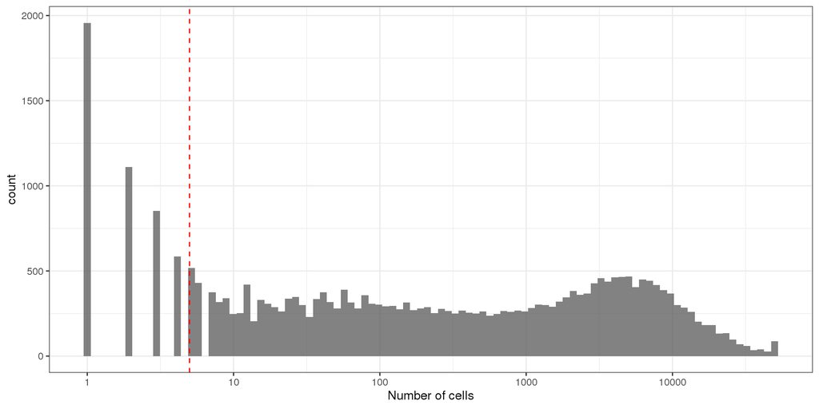

```r
n_cells <- Matrix::rowSums(tonsil_non_hashed[["RNA"]]@counts > 0)
gene_qc <- n_cells %>%
  as.data.frame() %>%
  ggplot(aes(n_cells)) +
    geom_histogram(bins = 100, alpha = 0.75) +
    scale_x_log10("Number of cells") +
    theme_bw()
gene_qc +
  geom_vline(xintercept = min_cells, linetype = "dashed", color = "red")
```

## 5.2 Plot genes with highest expression

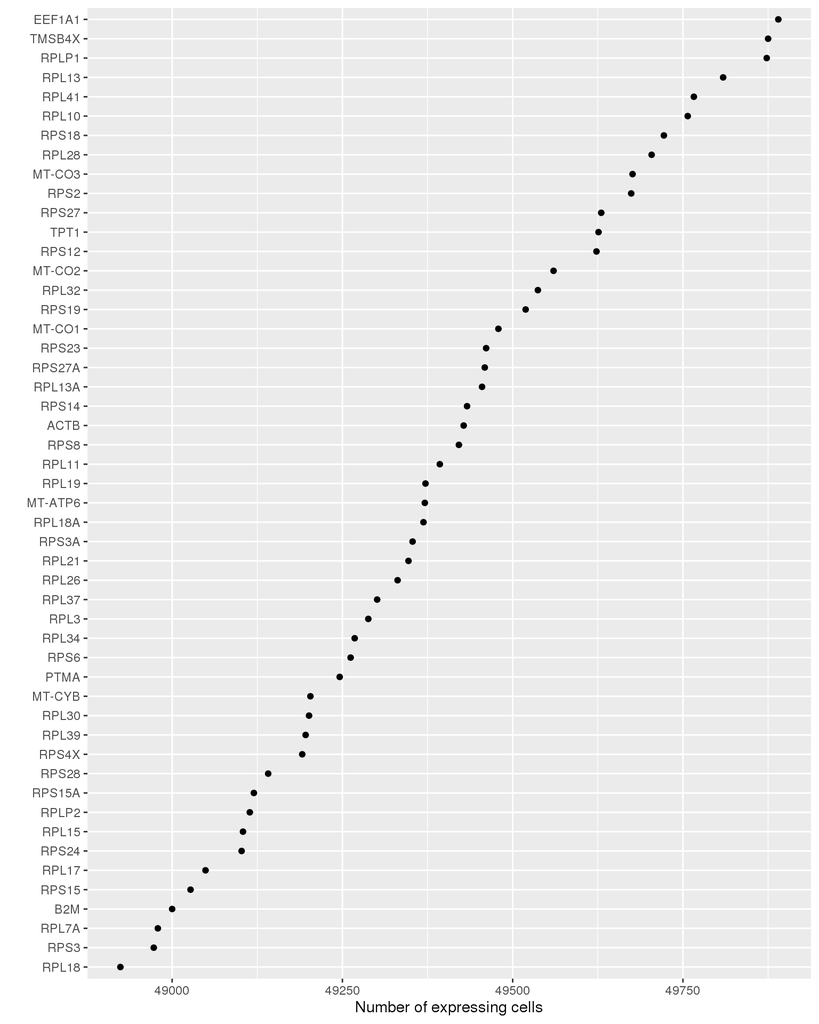

```r
top_50_genes <- sort(n_cells, decreasing = TRUE)[1:50]
top_50_genes_df <- data.frame(
  gene = names(top_50_genes),
  n_cells = top_50_genes
)
top_50_genes_df %>%
  ggplot(aes(fct_reorder(gene, n_cells), n_cells)) +
    geom_point() +
    labs(x = "", y = "Number of expressing cells") +
    coord_flip()
```

## 5.3 Filter

```r
kept_genes <- rownames(tonsil_non_hashed)[n_cells > min_cells]
table(n_cells > min_cells)
```

```
##
## FALSE  TRUE
## 12486 24115
```

```r
tonsil_non_hashed <- subset(tonsil_non_hashed, features = kept_genes)
tonsil_non_hashed
```

```
## An object of class Seurat
## 24115 features across 50072 samples within 1 assay
## Active assay: RNA (24115 features, 0 variable features)
```

# 6 Save filtered Seurat object

```r
saveRDS(tonsil_non_hashed, path_to_save_obj)
```